# Question 4: Portfolio Commentary

Vincent Reinshagen

November 2024

The Tracking Error indicates that the fund’s returns have deviated from the benchmark’s returns by an average of 5.07% annually.

```
## [1] 0.05068158
```

The cumulative returns of the SnakeOil Fund slightly lag behind the benchmark overall, though there are earlier periods where the fund outperformed the benchmark at certain points.

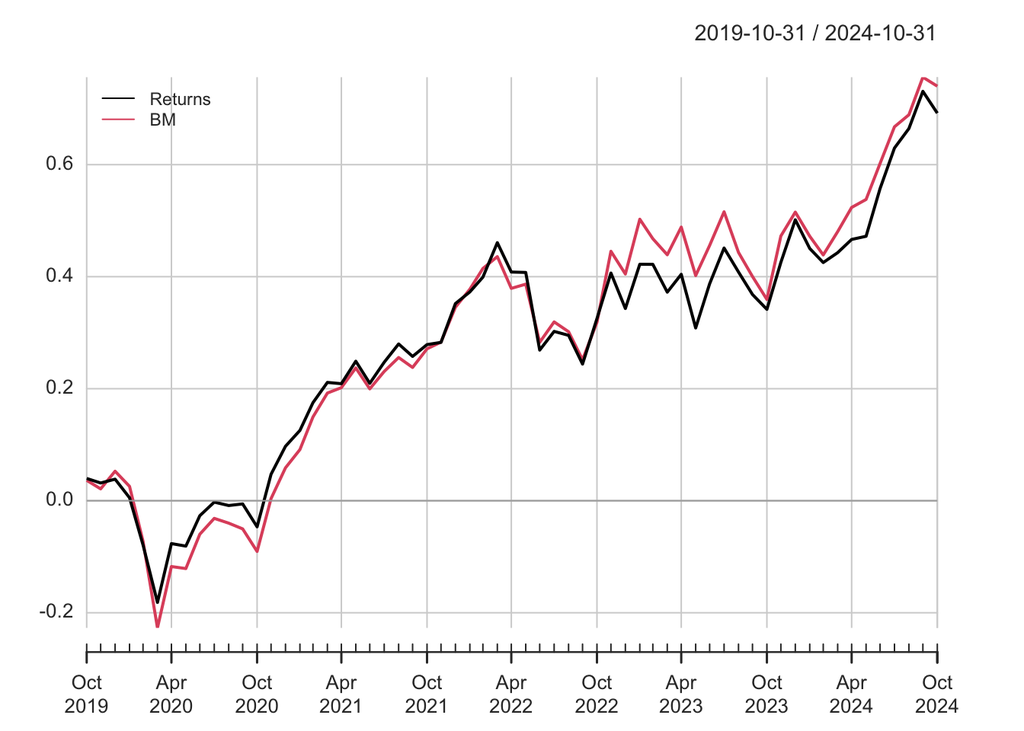

The rolling 12-month beta initially stayed near 1.0, suggesting alignment with the benchmark, then dropped below 1.0 around 2020, indicating reduced market sensitivity. The beta peaked above 1.1 in 2022, showing increased sensitivity to the benchmark before declining again, reflecting changing exposure and positioning relative to market movements.

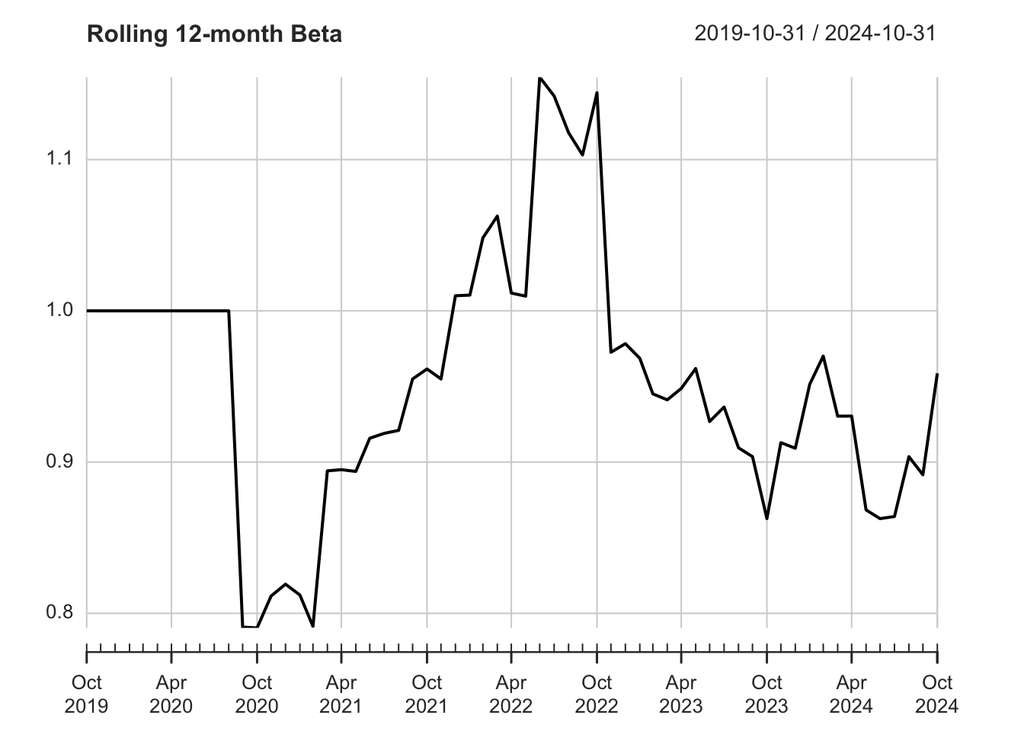

The relative performance chart shows how the fund’s cumulative returns have evolved compared to the benchmark over time. It highlights periods where the fund slightly outperformed or underperformed, with the ratio fluctuating close to 1.0, indicating generally tight alignment with the benchmark but with moments of relative underperformance becoming more prominent in recent periods.

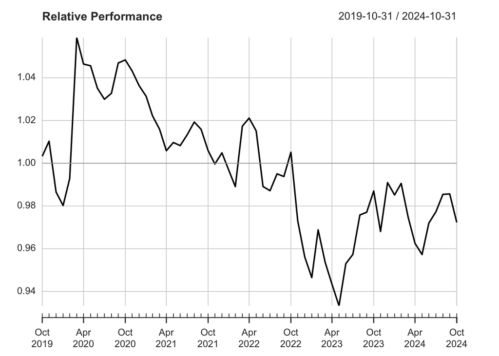

```
## [1] -4.693525
```

The fund demonstrates a high correlation (0.9568) and strong alignment with the benchmark (R-squared of 0.9155), but its active management has underperformed, as evidenced by a slightly negative annualized active premium (-0.0061) and an Information Ratio of -0.1233. While the fund has lower sensitivity to the benchmark (Beta of 0.8789) and moderate systematic risk compensation (Treynor Ratio of 0.1240), the minimal annualized alpha (0.0071) and tracking error (0.0498) indicate limited active value generation.

Table 1: Summary of Statistics from sfm

|  | Returns to BM |
| --- | --- |
| Alpha | 0.0006 |
| Beta | 0.8789 |
| Beta+ | 0.8427 |
| Beta- | 0.7612 |
| R-squared | 0.9155 |
| Annualized Alpha | 0.0071 |
| Correlation | 0.9568 |
| Correlation p-value | 0.0000 |
| Tracking Error | 0.0498 |
| Active Premium | -0.0061 |
| Information Ratio | -0.1233 |
| Treynor Ratio | 0.1240 |